# Homework 6

Yuvraj Jain

March 31, 2023

# Instructions

**Exercises:** 4 (Pg. 302); 1 (Pgs. 316-317); 1 (Pgs. 328-329); 1, 2 (Pgs. 353-354)

**Submission:** Submit via an electronic document on Sakai. Must be submitted as a HTML file generated in RStudio. All assigned problems are chosen according to the textbook *R for Data Science*. You do not need R code to answer every question. If you answer without using R code, delete the code chunk. If the question requires R code, make sure you display R code. If the question requires a figure, make sure you display a figure. A lot of the questions can be answered in written response, but require R code and/or figures for understanding and explaining.

# Chapter 16 (Pg. 302)

## Exercise 4: Create functions that take a vector as input and return:

### a) The last value. Should you use [ or [[ ?

```r
last_value <- function(x) {
  # check for case with no length
  if (length(x) != 0) {
    x[[length(x)]]
  } else {
    x
  }
}

last_value(1:10)
```

```
## [1] 10
```

The function uses `[[` in order to extract a single element.

### b) The elements at even numbered positions.

```r
even_positions <- function(x) {
   if (length(x) != 0) {
    x[seq_along(x) %% 2 == 0]
  } else {
    x
  }
}

even_positions(1:10)
```

```
## [1]  2  4  6  8 10
```

### c) Every element except the last value.

```r
except_last <- function(x) {
  if (length(x) != 0) {
    x[1:length(x)-1]
  } else {
    x
  }
}

except_last(1:10)
```

```
## [1] 1 2 3 4 5 6 7 8 9
```

### d) Only even numbers (and no missing values)

```r
even_numbers <- function(x) {
  x[x %% 2 == 0]
}

even_numbers(1:10)
```

```
## [1]  2  4  6  8 10
```

# Chapter 17 (Pgs. 316-317)

## Exercise 1: Write for loops to:

### a) Compute the mean of every column in `mtcars`

```r
output <- vector("double", ncol(mtcars))
for (i in seq_along(mtcars)) {
  output[i] <- mean(mtcars[,i])
}
output
```

```
##  [1]  20.090625   6.187500 230.721875 146.687500   3.596563   3.217250
##  [7]  17.848750   0.437500   0.406250   3.687500   2.812500
```

### b) Determine the type of each column in nyc flights13::flights

```r
output <- vector("character", ncol(flights))
for (i in seq_along(flights)) {
  col_class <- class(flights[[i]])
  if (length(col_class) == 1) {
    output[i] <- col_class
  } else {
    output[i] <- paste0(col_class, collapse = "/")
  }
}
```

### c) Compute the number of unuique values in each column of `iris`

```r
data("iris")
output <- vector("double", ncol(iris))
names(output) <- names(iris)
for (i in names(iris)) {
  output[i] <- length(unique(iris[,i]))
}
output
```

```
## Sepal.Length  Sepal.Width Petal.Length  Petal.Width      Species
##           35           23           43           22            3
```

### d) Generate 10 random normals for each of $\mu = -10, 0, 10,$ and $100$. Think about the output, sequence, and body before you start writing the loop.

```r
mu <- c(-10, 0, 10, 100)
output <- vector("list", 4)
for (i in seq_along(output)) {
  output[[i]] <- rnorm(10, mean = mu[i])
}
output
```

```
## [[1]]
##  [1] -10.830102 -10.046806  -8.891359 -10.985723  -9.004340 -11.905687
##  [7]  -8.824001  -9.848394  -8.490548 -10.775784
##
## [[2]]
##  [1]  0.56806823 -0.33284323  0.68015611 -0.69224149  0.54245111  0.02632036
##  [7] -0.83854253 -0.00322762 -1.15874256 -1.00054502
##
## [[3]]
##  [1]  8.368909 10.081653 10.465736 11.150425 10.144916 11.498615  8.585874
##  [8]  7.828447 10.773121 10.841695
##
## [[4]]
##  [1]  99.38592  99.49661 100.28655  99.69261 100.23525  99.97709  99.57397
##  [8] 101.59653 100.53782  98.94475
```

# Chapter 17 (Pgs. 328-329)

## Exercise 1: Write code that uses one of the map functions to:

### a) Compute the mean of every column in `mtcars`

```r
map_dbl(mtcars, mean)
```

```
##        mpg        cyl       disp         hp       drat         wt       qsec
##  20.090625   6.187500 230.721875 146.687500   3.596563   3.217250  17.848750
##         vs         am       gear       carb
##   0.437500   0.406250   3.687500   2.812500
```

### b)

```r
map_chr(flights, typeof)
```

```
##           year          month            day       dep_time sched_dep_time
##      "integer"      "integer"      "integer"      "integer"      "integer"
##      dep_delay       arr_time sched_arr_time      arr_delay        carrier
##       "double"      "integer"      "integer"       "double"    "character"
##         flight        tailnum         origin           dest       air_time
##      "integer"    "character"    "character"    "character"       "double"
##       distance           hour         minute      time_hour
##       "double"       "double"       "double"       "double"
```

### c)

```r
map_int(iris, n_distinct)
```

```
## Sepal.Length  Sepal.Width Petal.Length  Petal.Width      Species
##           35           23           43           22            3
```

### d)

```r
map(c(-10, 0, 10, 100), ~rnorm(n = 10, mean = .))
```

```
## [[1]]
##  [1] -12.162267  -9.813198 -11.231101 -10.683726 -11.100328 -11.678904
##  [7]  -9.129816  -9.950498 -11.265390 -10.143861
##
## [[2]]
##  [1]  0.06418306  1.44477770 -0.42414858  0.38130598  0.23680671 -1.58376408
##  [7]  0.47422036  0.68043480  1.72207677 -0.93425058
##
## [[3]]
##  [1] 10.166455  9.944991 10.525693 11.001852  9.148032 10.127063 11.483340
##  [8] 10.099792 10.618005  8.860791
##
## [[4]]
##  [1]  99.61905  99.34421 101.27609  99.56555  99.84425 100.54239 100.86692
##  [8]  97.85508  98.68235  99.18778
```

# Chapter 18 (Pgs. 353-354)

## Exercise 1:

One downside of the linear model is that it is sensitive to unusual values because the distance incorporates a squared term. Fit a linear model to the following simulated data, and visualize the results. Rerun a few times to generate different simulated datasets. What do you notice about the model?

```r
sim1a <- tibble(
  x = rep(1:10, each = 3),
  y = x * 1.5 + 6 + rt(length(x), df = 2)
)
head(sim1a)
```

```
## # A tibble: 6 × 2
##       x     y
##   <int> <dbl>
## 1     1  7.91
## 2     1 11.8
## 3     1  8.89
## 4     2  9.30
## 5     2  5.13
## 6     2  8.40
```

Runnning it once to see the results:

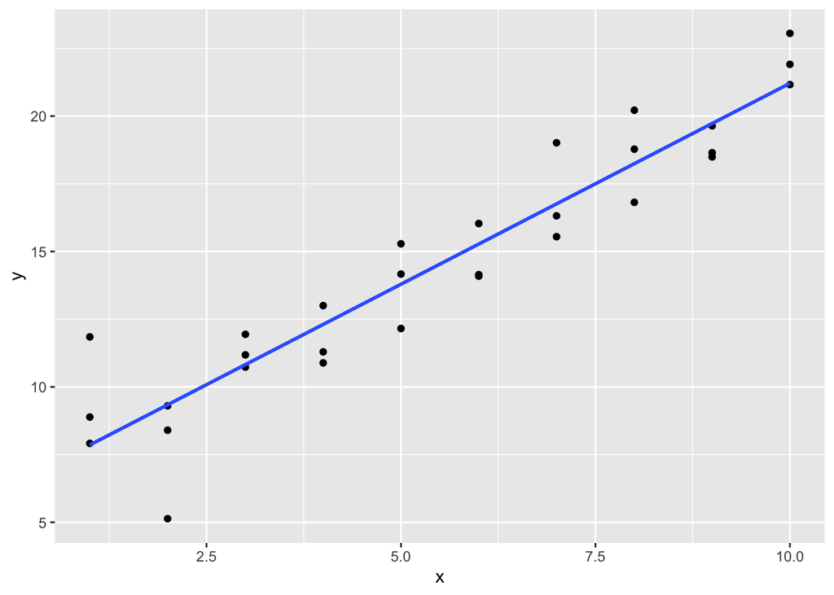

```r
ggplot(sim1a, aes(x = x, y = y)) +
  geom_point() +
  geom_smooth(method = "lm", se = FALSE)
```

Running the code a few times, a noticed that the slope gets skewed a lot by the outliers. Especially the y values when x = 10.0. If these values are really low or really high, the slope can vary by a lot.

## Exercise 2:

One way to make linear models more robust is to use a different distance measure. For example, instead of root-mean-squared distance, you could use mean-absolute distance:

Use optim() to fit this model to the previous simulated data and compare it to the linear model.

```r
measure_distance <- function(mod, data) {
          diff <- data$y - make_prediction(mod, data)
          mean(abs(diff))
}
```

For the above function to work, we need to define a function, make_prediction(), that takes a numeric vector of length two (the intercept and slope) and returns the predictions,

```r
make_prediction <- function(mod, data) {
  mod[1] + mod[2] * data$x
}
```

Using the sim1a data, the best parameters of the least absolute deviation are:

```r
best <- optim(c(0, 0), measure_distance, data = sim1a)
best$par
```

```
## [1] 6.447845 1.466006
```

Using the sim1a data, while the parameters the minimize the least squares objective function are:

```r
measure_distance_ls <- function(mod, data) {
  diff <- data$y - (mod[1] + mod[2] * data$x)
  sqrt(mean(diff^2))
}

best <- optim(c(0, 0), measure_distance_ls, data = sim1a)
best$par
```

```
## [1] 6.371337 1.484014
```